# Love Intesinity by Gender and Relationships Impact on Overall Love

Author

Andrew Negrette

## Hypothesis 1

Women will score higher on intensity of love compared to men.

### Variables and descriptive statistics

- **Gender (`Sex`):** A categorical variable with three groups: Men, Women, and Prefer not to say
- **Intesnity of Love (`Love_how_much_1`):** Points allocated to intesnity of love from a total budget of 100 points. Higher values indicate greater love intensity.

```r
# Count respondents in each group.
table(h1Data$Sex)
```

```
              Men             Women Prefer not to say
            17155             37673               203
```

```r
# Summarize love intesity points separately for each group.
by(h1Data$Love_how_much_1, h1Data$Sex, summary)
```

```
h1Data$Sex: Men
   Min. 1st Qu.  Median    Mean 3rd Qu.    Max.
   0.00   78.00   92.00   85.43  100.00  100.00
------------------------------------------------------------
h1Data$Sex: Women
   Min. 1st Qu.  Median    Mean 3rd Qu.    Max.
   0.00   80.00   95.00   87.23  100.00  100.00
------------------------------------------------------------
h1Data$Sex: Prefer not to say
   Min. 1st Qu.  Median    Mean 3rd Qu.    Max.
   0.00   70.50   90.00   83.02  100.00  100.00
```

### Graph

Figure 1 shows the distribution of points by sex at birth. The half-violin shows the shape of the distribution, the box summarizes the median and quartiles, and the dots represent individual responses.

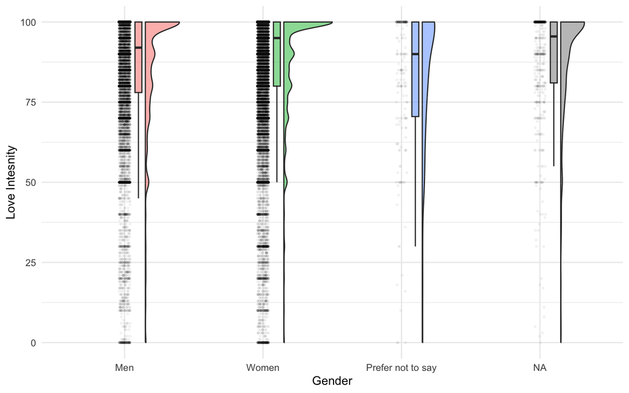

Figure 1: Love Intesitiy, by Gender.

```r
ggplot(h1Data, aes(x = Sex, y = Love_how_much_1,
                   fill = Sex)) +
  geom_rain(alpha = 0.5, point.args = list(alpha = 0.04, size = 0.6, na.rm = T)) +
  labs(x = "Gender", y = "Love Intesnity") +
  theme_minimal() +
  theme(legend.position = "none")
```

Overall romantic love will positively correlate with relationship duration.

### Variables and descriptive statistics

- **Relationship Length (`Relationship_length`):** A single item asking how long their current relatioship is in years.
- **Overall Romantic Love (`all_love_score`):** The mean of available responses to `Love_1–15`. Each item ranges from 1 (Not at all) to 5 (Extremely); higher scores indicate greater overall love

```r
summary(h2Data[, c("Relationship_length", "all_love_score")])
```

```
 Relationship_length all_love_score
 Min.   : 1.000      Min.   :1.000
 1st Qu.: 2.000      1st Qu.:3.667
 Median : 4.000      Median :4.267
 Mean   : 8.397      Mean   :4.087
 3rd Qu.:11.000      3rd Qu.:4.733
 Max.   :80.000      Max.   :5.000
```

### Graph

Figure 2 shows the relationship between realtionship length and overall love. Points are jittered to make overlapping responses easier to see; the recorded scores are unchanged. The line summarizes the linear trend.

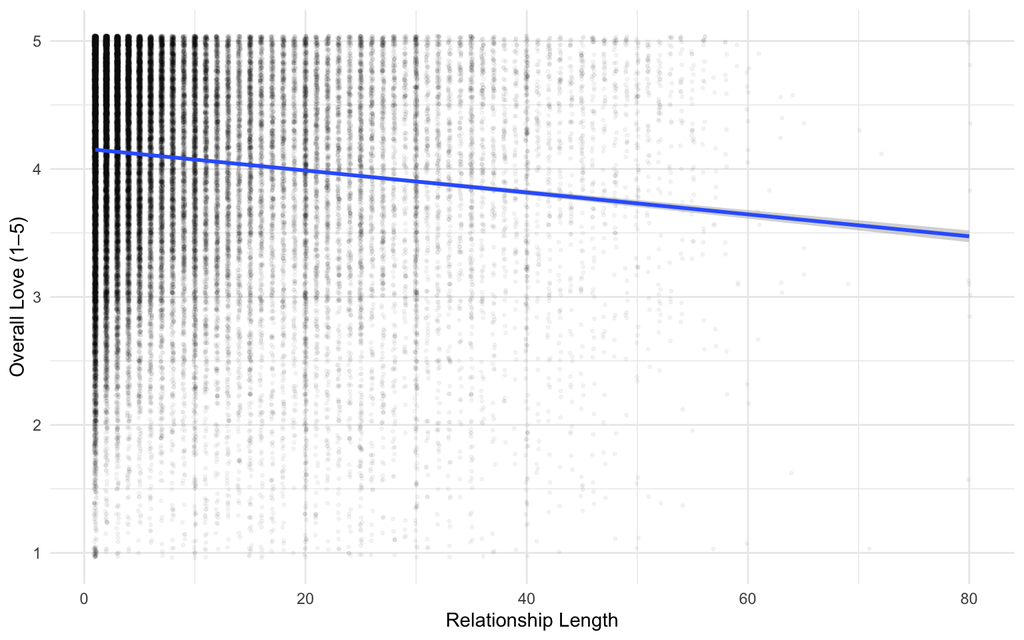

Figure 2: Relationship between relationship length and overall love.

```r
ggplot(h2Data, aes(x = Relationship_length,
                   y = all_love_score)) +
  geom_jitter(width = .12, height = .04,
              alpha = .04, size = .6) +
  geom_smooth(method = "lm") +
  labs(x = "Relationship Length",
       y = "Overall Love (1–5)") +
  theme_minimal()
```

### Observed trend

```r
r <- cor(h2Data$Relationship_length, h2Data$all_love_score, use = "complete.obs")
round(r, 2)
```

```
[1] -0.11
```

The correlation was -0.11, indicating a weak negative association.